# Build model to estimate Y1k

```r
datawt <- read.csv2("Modeling_C.csv",sep = ",",header = TRUE,na.strings = c(" "))

datawt$X1 <- as.numeric(datawt$X1)
datawt$X2 <- as.numeric(datawt$X2)
datawt$X3 <- as.numeric(datawt$X3)
datawt$X4 <- as.numeric(datawt$X4)

head(datawt)
```

```
##     X1   X2   X3   X4 Y1 Y2
## 1 2153 1178 1918  622  0  0
## 2 6586 1178 6482  485  0  0
## 3  978 1178  756  813  1  1
## 4 1345 1178 1108  668  0  0
## 5 6770 1178 6704  874  0  0
## 6 3190 1178 2895 1120  0  0
```

Step 1.2: Check missing value using and range of the values using sapply.

```r
sapply(datawt,function(x) sum(is.na(x)))
```

```
## X1 X2 X3 X4 Y1 Y2
##  0  0  0  0  0  0
```

```r
sapply(datawt,function(x) length(unique(x)))
```

```
##   X1   X2   X3   X4   Y1   Y2
## 6812 1223 6740 6213    2    2
```

Step 1.3 A visual take on the missing values might be helpful: the Amelia package has a special plotting function missmap() that will plot your dataset and highlight missing values:

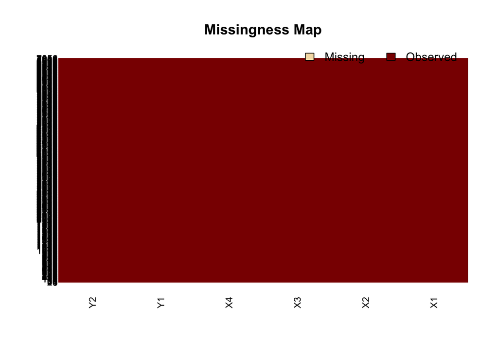

```r
library(Amelia)
library(Rcpp)
missmap(datawt)
```

Observation: There are no missing values. The data can be used obtain a good fit of the model and better predictive ability.

Step 2 Check Class Bias Ideally, the proportion of events and non-events in the Y1 variable should approximately be the same. So, lets first check the proportion of classes in the dependent variable Y1.

```r
table(datawt$Y1)
```

```
##
##    0    1
## 4899 2157
```

Clearly, there is a class bias, a condition observed when the proportion of events is much smaller than the proportion of non-events. So we must sample the observations in approximately equal proportions to get better models.

Create Training and Test Samples. One way to address the problem of class bias is to draw the 0’s and 1’s for the given sample data in equal proportions. In doing so, we will put rest of the input data not included for training into testData (validation sample). As a result, the size of development sample will be smaller that validation, which is okay, because, there is a large number of observations (>7K).

```r
#Create traning data
datawt_input_1 <-  subset(datawt,datawt$Y1 == 1)
datawt_input_0 <- subset(datawt,datawt$Y1 == 0)
table(datawt_input_1$Y1)
```

```
##
##    1
## 2157
```

```r
table(datawt_input_0$Y1)
```

```
##
##    0
## 4899
```

```r
set.seed(100)

datawt_rows_input_1 <- sample(1:nrow(datawt_input_1),round(0.7*nrow(datawt_input_1)))
datawt_rows_input_0 <- sample(1:nrow(datawt_input_0),round(0.7*nrow(datawt_input_1)))

train_datawt_1 <- datawt_input_1[datawt_rows_input_1,]
train_datawt_0 <- datawt_input_0[datawt_rows_input_0,]

datawt_sample <- rbind(train_datawt_1,train_datawt_0)


#Create Test Data
test_ones <- datawt_input_1[-datawt_rows_input_1, ]
test_zeros <- datawt_input_0[-datawt_rows_input_0, ]
testData <- rbind(test_ones, test_zeros)


head(datawt_sample)
```

```
##        X1   X2   X3   X4 Y1 Y2
## 3251 1116 1178  884 1006  1  1
## 2942 2178  224 2038 5117  1  1
## 4670  667 1178  462 2866  1  1
## 848  4948 1178 4788 1359  1  0
## 4180 2280 1178 2037  952  1  0
## 4241    6  651 2097 4885  1  0
```

```r
table(datawt_sample$Y1)
```

```
##
##    0    1
## 1510 1510
```

```r
#datawt_train <- sample(1:nrow(datawt),0.7*nrow(datawt))
#datawt_train <- datawt[datawt_train,]

#datawt_test  <- sample(1:nrow(datawt),0.3*nrow(datawt))
#datawt_test  <- datawt[datawt_test,]
```

Step 4: Build Logit Models

```r
model <- glm(Y1~X1+X2+X3+X4 ,data=datawt_sample,family=binomial(link="logit"))
summary(model)
```

```
##
## Call:
## glm(formula = Y1 ~ X1 + X2 + X3 + X4, family = binomial(link = "logit"),
##     data = datawt_sample)
##
## Deviance Residuals:
##      Min        1Q    Median        3Q       Max
## -1.95568  -1.00955   0.02276   0.87891   2.05439
##
## Coefficients:
##               Estimate Std. Error z value Pr(>|z|)
## (Intercept)  1.678e+00  1.965e-01   8.541  < 2e-16 ***
## X1          -3.967e-04  4.537e-05  -8.745  < 2e-16 ***
## X2          -4.886e-04  1.623e-04  -3.010  0.00261 **
## X3          -6.106e-05  4.396e-05  -1.389  0.16481
## X4           6.391e-05  2.363e-05   2.705  0.00684 **
## ---
## Signif. codes:  0 '***' 0.001 '**' 0.01 '*' 0.05 '.' 0.1 ' ' 1
##
## (Dispersion parameter for binomial family taken to be 1)
##
##     Null deviance: 4186.6  on 3019  degrees of freedom
## Residual deviance: 3627.6  on 3015  degrees of freedom
## AIC: 3637.6
##
## Number of Fisher Scoring iterations: 4
```

Step 5: Predict and visualize the test data.

Receiver Operating Characteristics Curve traces the percentage of true positives accurately predicted by a given logit model as the prediction probability cutoff is lowered from 1 to 0. For a good model, as the cutoff is lowered, it should mark more of actual 1’s as positives and lesser of actual 0’s as 1’s.

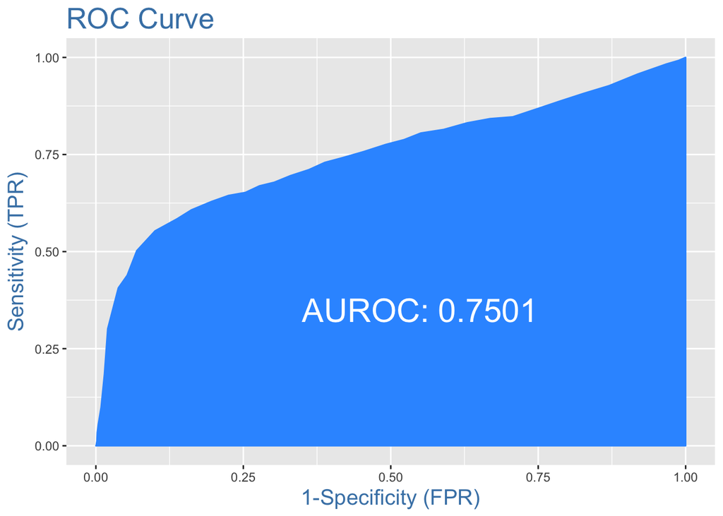

```r
# Apply the mode to remaining data
predicted <- predict(model, testData, type="response")

library(InformationValue)
optCutOff <- optimalCutoff(testData$Y1, predicted)[1]

plotROC(testData$Y1, predicted)
```

```r
anova(model, test="Chisq")
```

```
## Analysis of Deviance Table
##
## Model: binomial, link: logit
##
## Response: Y1
##
## Terms added sequentially (first to last)
##
##
##      Df Deviance Resid. Df Resid. Dev  Pr(>Chi)
## NULL                  3019     4186.6
## X1    1   540.57      3018     3646.0 < 2.2e-16 ***
## X2    1     9.42      3017     3636.6  0.002150 **
## X3    1     1.67      3016     3634.9  0.196378
## X4    1     7.37      3015     3627.6  0.006632 **
## ---
## Signif. codes:  0 '***' 0.001 '**' 0.01 '*' 0.05 '.' 0.1 ' ' 1
```

Observation

The above model has an area under ROC curve 75.01%, which is good.

Example: Module to get the probability y1 = 1

Before we noted that the logistic function outputs the probability that Y1 = 1 for a given value of x1, x2,x3,x4. In this example, P(value=1) – the probability that value is 1 – if they had x1, x2, x3, x4 would be equal to:

```r
x1 <- 978
x2 <- 1178
x3 <- 756
x4 <- 813


equ = model$coefficients[1] + x1*model$coefficients[2] + x2*model$coefficients[3] + x3*model$coefficients[4] + x4 * model$coefficients[5]

y1 <- exp((equ)) / (1 + exp((equ)))

as.numeric(y1)
```

```
## [1] 0.6727076
```

As per above build model the probabilty to get value of y1 = 1 is 67.27 %, when x1 <- 978, x2 <- 1178, x3 <- 756, x4 <- 813

To predict pr(1) the following steps are required